# STATS 406, Homework 01

Jiawei Hao, hjiawei

Due 2021-09-08 at 11:59pm

## Setup

Make sure that you have the `tidyverse` and `ggplot2` packages installed. You can run the following in your terminal to make sure that these are up to date:

```r
install.packages(c("tidyverse", "ggplot2"))
```

After they are installed, the following lines should work without error:

```r
library(tidyverse)
library(ggplot2)
```

## Problem 1 (2 pts)

### Part (a) (1 pt)

The following block of text is adapted from the [Wikipedia page on R](https://en.wikipedia.org/wiki/R_(programming_language). If you look at the source code for this document (the .Rmd file), you will see that the text is in HTML format. Your job is to recreate the RMarkdown I used to create this formatting.

- [Markdown basics](https://www.markdownguide.org/basic-syntax/)
- [RMarkdown additional details](http://rmarkdown.rstudio.com)
- The `Help > Cheatsheets > R Markdown Cheat Sheet` menu option
- You may find it easiest to copy the text from the rendered HTML into this .Rmd file, and then perform the necessary formatting.
- For the block of R code, you do not need to actually execute this code. (Use `eval = FALSE` in the chunk header)
- The Mandelbrot image can be found at `https://upload.wikimedia.org/wikipedia/commons/thumb/a/a7/Mandelbrot_Creation_Animation.gif/400px-Mandelbrot_Creation_Animation.gif`

## Mandelbrot set

```r
install.packages("caTools")  # install external package
library(caTools)             # external package providing write.gif function
jet.colors <- colorRampPalette(c("red", "blue", "#007FFF", "cyan", "#7FFF7F",
                                 "yellow", "#FF7F00", "red", "#7F0000"))
dx <- 1500                    # define width
dy <- 1400                    # define height
C  <- complex(real = rep(seq(-2.2, 1.0, length.out = dx), each = dy),
              imag = rep(seq(-1.2, 1.2, length.out = dy), dx))
C <- matrix(C, dy, dx)       # reshape as square matrix of complex numbers
Z <- 0                       # initialize Z to zero
X <- array(0, c(dy, dx, 20)) # initialize output 3D array
for (k in 1:20) {            # loop with 20 iterations
  Z <- Z^2 + C               # the central difference equation
  X[, , k] <- exp(-abs(Z))   # capture results
}
write.gif(X, "Mandelbrot.gif", col = jet.colors, delay = 100)
```

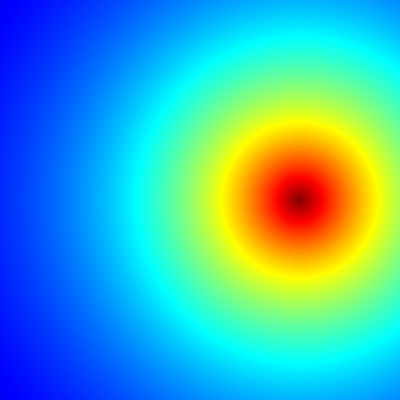

### Part (b) (1 pt)

Section 2.3 of Statistical Computing with R (by Maria Rizzo) gives the Normal distribution probability density function. Recreate the definition using math notation in RMarkdown. [Cosma Shazili’s reference](http://www.stat.cmu.edu/~cshalizi/rmarkdown/#math-in-r-markdown) is very helpful.

$$\begin{eqnarray}
f(x) &= \frac{1}{\sqrt{2\pi}\sigma}exp\{-\frac{1}{2}(\frac{x-\mu}{\sigma})^2\}
\end{eqnarray}$$

## Problem 2 (4 pts)

In this problem we will write three versions of functions to compute the (sample) mean and (sample) variance a numeric vector.

Sample mean is defined as
$$\bar x = \frac{1}{n} \sum_{i = 1}^n x_i$$

Sample variance is defined as
$$S^2 =\frac{1}{n - 1} \sum_{i = 1}^n (x_i - \bar x)^2$$

Demonstrate that you get the same answers as the R built in versions of these functions.

```r
x <- c(30,290,14,88,32,56)
mean(x) # R's built in mean function
```

```
## [1] 85
```

```r
var(x) # R's built in variance function
```

```
## [1] 10750
```

Hint: to get $n$ in the above equations you can use `length(x)`.

## Part a (1 pt)

This solution should be written using `for` loops to explicitly iterate through `x`.

```r
mean_for <- function(x) {
  sum <- 0
  for (value in x){
    sum <- sum + value
  }
  mean = sum / length(x)
  return(mean)
}

var_for <- function(x) {
  mean = mean_for(x)
  sum <- 0
  for (value in x){
  sum = sum + (value - mean)^2
  }
  variance = sum/(length(x) - 1)
  return (variance)
}

mean_for(x)
```

```
## [1] 85
```

```r
var_for(x)
```

```
## [1] 10750
```

## Part b (1 pt)

This solution should be written using the `map_dbl` and `reduce` functions to handle the iteration.

```r
mean_map <- function(x) {
  sum = reduce(x, ~ .x+.y, init = 0)
  mean = sum / length(x)
  return(mean)
}

var_map <- function(x) {
  mean = mean_map(x)
  sum_vec = map_dbl(x, ~ (.x-mean)^2)
  sum = reduce(sum_vec, ~ .x+.y, ini = 0)
  var = sum/(length(x)-1)
  return(var)
}

mean_map(x)
```

```
## [1] 85
```

```r
var_map(x)
```

```
## [1] 10750
```

## Part c (1 pt)

This solution should be written using R’s vector math operations and R’s `sum` function.

```r
mean_vec <- function(x) {
  return(sum(x)/length(x))
}

var_vec <- function(x) {
  mean = mean_vec(x)
  dis = x - mean
  dis_sq = dis^2
  var = sum(dis_sq)/(length(x)-1)
  return(var)
}

mean_vec(x)
```

```
## [1] 85
```

```r
var_vec(x)
```

```
## [1] 10750
```

## Part d (1 pt)

Using any method of calculating $\bar X_n$ and $S_n$, write a function that computes the standardized mean of a sample (also known as the Z-score):
$$Z_n = \frac{\bar X_n}{\sqrt{S^2} / \sqrt{n}}$$

Demonstrate your function applied to the vector `x` defined for this problem.

```r
mean_vec <- function(x) {
  return(sum(x)/length(x))
}

var_vec <- function(x) {
  mean = mean_vec(x)
  dis = x - mean
  dis_sq = dis^2
  var = sum(dis_sq)/(length(x)-1)
  return(var)
}

z_score <- function(x) {
  mean = mean_vec(x)
  var = var_vec(x)
  z = mean / (sqrt(var)/sqrt(length(x)))
  return(z)
}

z_score(x)
```

```
## [1] 2.008123
```

## Problem 3 (4 pts)

Spotify publishes an [API for playlists, tracks, and user data](https://developer.spotify.com/documentation/web-api/). I’ve already retrieved some data from Spotify, included in the the `tracks.rda` file included with this homework. One neat aspect of Spotify’s data is the [audio features](https://developer.spotify.com/documentation/web-api/reference/tracks/get-several-audio-features/). These features rate tracks on many qualities such as “danceability” or whether the track seems to be “acoustic.” We will investigate the relationships between these qualities for nearly 1000 tracks.

To use the data, place `tracks.rda` in the same directory as this file. Before knitting this file, use the `Session -> Set Working Directory -> To Source File Location` menu so that following line will load the data and display a few of the columns in the table.

```r
load("tracks.rda")
knitr::kable(tracks[c(1,2,335), c("track.album.name", "track.name", "danceability", "energy", "key", "loudness", "mode")])
```

[output not shown]

```r
dim(tracks)
```

```
## [1] 967  57
```

### Part a (2 pt)

We’ll start by just getting a feeling for the data by answering the following questions.

- What is the mean danceability score of all tracks?
- For tracks with danceability above the mean, what is the median duration?
- For each key, summarize mean loudness level? (Hint: use the `group_by` and `summarize` functions.)

```r
dance = tracks[c(1:967),c("danceability")]
paste("mean danceability is ", mean(dance))
```

```
## [1] "mean danceability is  0.597629472595657"
```

```r
new.track <- filter(tracks,dance>mean(dance))
paste("median duration is", median(new.track[["track.duration_ms"]]))
```

```
## [1] "median duration is 194898"
```

```r
data = group_by(tracks[("loudness")],tracks[("key")])
summ = summarise_all(data,mean)
paste("mean loudness for each key is ",view(summ))
```

```
## [1] "mean loudness for each key is  0:11"
## [2] "mean loudness for each key is  c(-8.27498230088496, -7.60695412844037, -8.87466666666667, -8.73, -8.18181818181818, -8.23646575342466, -8.64775308641975, -7.980464, -7.28091111111111, -10.0289012345679, -8.75784507042254, -8.34023287671233)"
```

### Part b (2 pt)

Since tracks can have multiple artists, the “track.artists” column is composed of lists with information on each artist that contributes to the track. To make display a little easier, your first task is to create a new column for the `tracks` that just display’s all the artists as a single bit of text. To demonstrate your results, create the previous table with the addition of the artist names.

Some useful functions:

- `mutate` will return a new table with one or more new columns added
- `map_chr` will iterate across a list or vector and return text (“character vector” in R terminology). ([More information on `map` functions](https://r4ds.had.co.nz/iteration.html#the-map-functions).)
- `paste` will join its arguments into a single character vector. See the `collapse` argument in particular.

```r
art <- tracks["track.album.artists"]
ls <- art[[1]]
lst1 <- map(ls, ~ .x[[3]],paste)
track2 <- mutate(tracks,lst1)
```

[output not shown]